# Data manipulation and advanced plotting

Elizabeth Oladapo

Last modified: 12 March 2023

In this section, we will introduce new graphic styles with histogram, boxplots and faceting, scatterplot customization methods and data summaries for example, calculating means, standard deviations and standard errors.

### 1. Download additional datasets

In this section, you will use the adult mortality rate dataset. Download all the datasets we will be using in this course: [R_course_datasets](https://drive.google.com/drive/folders/17glWVCgvnoTAPKUdcdO_MhCXSSCmQO6P?usp=sharing) and move it into the data folder in your project folder (“R-training”) on your local machine

This data is extracted from WHO

The World Health Organization (WHO) defines adult mortality rate as the probability that a 15 year old person will die before reaching his/her 60th birthday. The probability of dying between the ages of 15 and 60 years (per 1000 population) per year among a hypothetical cohort of 100,000 people that would experience the age-specific mortality rate of the reporting year.

**Note:** You will need to set up another script for the section. You may name your new script “Data manipulation and advanced plotting”.

Set up your annotated sections such as description of your work, loading the packages, data import, and checking the data.

```r
### Working with adult mortality rate data
## load the required packages

library("tidyverse")
## Import the data
Mortality <- read_csv("./data/Mortality.csv")
```

```
## -------------------------------------------------------- Delimiter: "," chr
## (2): ParentLocation, Location dbl (3): ...1, Period, Adult_mortality_rate
```

```r
## check the data
glimpse(Mortality)
```

```
## Rows: 3,111
## Columns: 5
## $ ...1                 <dbl> 0, 1, 2, 3, 4, 5, 6, 7, 8, 9, 10, 11, 12, 13, 14,~
## $ ParentLocation       <chr> "Americas", "Europe", "Europe", "Europe", "Wester~
## $ Location             <chr> "Barbados", "Serbia", "Turkey", "Slovakia", "Samo~
## $ Period               <dbl> 2016, 2016, 2016, 2016, 2016, 2016, 2016, 2016, 2~
## $ Adult_mortality_rate <dbl> 100.4, 102.5, 104.0, 104.1, 110.4, 110.5, 110.6, ~
```

### 2. Generating histograms

A histogram is a graphical representation of data points organized into user-specified ranges.

It shows the distribution of numerical data (There are many different classifications of probability distributions. Some of them include the normal distribution, chi square distribution, binomial distribution, and Poisson distribution).

Histograms are sometimes confused with bar charts. A histogram is used for continuous data, where the bins represent ranges of data, while a bar chart is a plot of categorical variables. Some authors recommend that bar charts have gaps between the rectangles to clarify the distinction.

Note that in histograms aesthetics are only based on one variable.

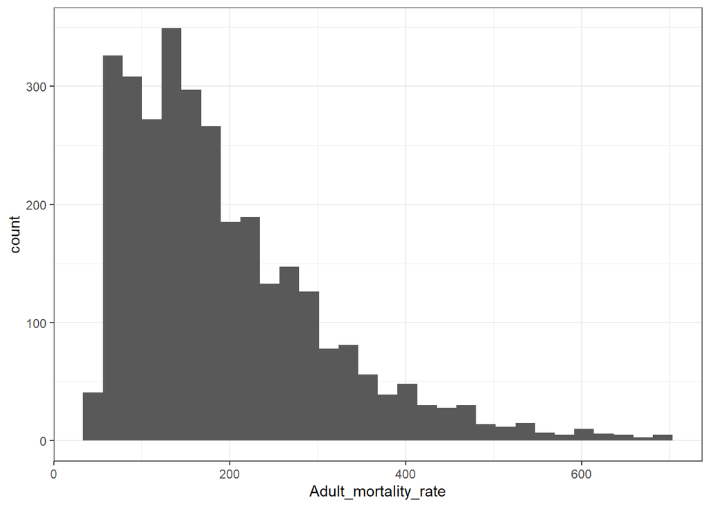

```r
## Generating a histogram

# Looking at the distribution of Adult mortality rate
ggplot(Mortality, aes(x=Adult_mortality_rate))+
  geom_histogram()+
  theme_bw() #get rid of the grey background
```

By default, the underlying computation of geom_histogram through stat_bin uses 30 bins, which is not always a good default.

This is the reason why you get the following message every time you create a default histogram in ggplot2:

```
stat_bin() using bins = 30. Pick better value with `binwidth`.
```

You can pick better value with binwidth or bins

• The number of bins or bars of the histogram can be customized with the bins argument of the geom_histogram function.

• The binwidth argument of the geom_histogram function. This argument controls the width of each bin along the X-axis

Divide the histogram into groups based on the ParentLocation variable to allow us see the histograms of each continent.

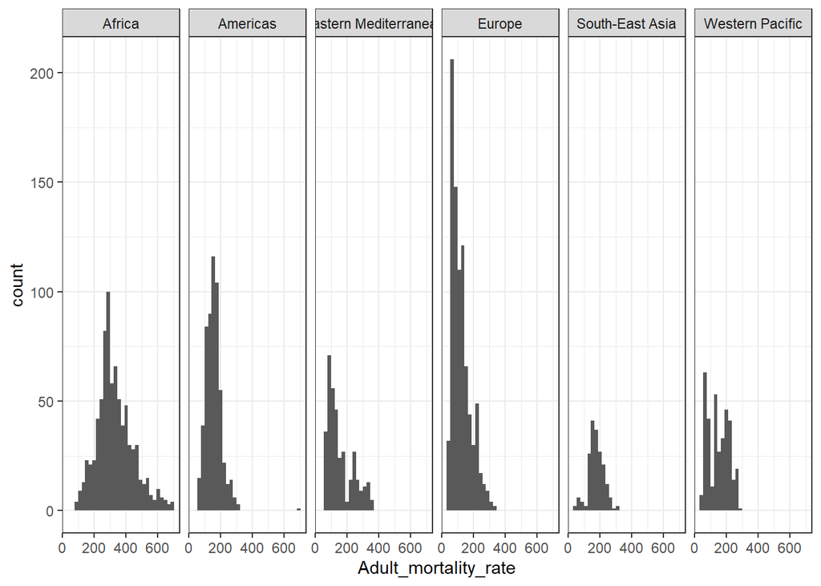

```r
## Generating a histogram

# Looking at the distribution of Adult mortality rate
ggplot(Mortality, aes(x=Adult_mortality_rate))+
  geom_histogram()+
  facet_grid(. ~ ParentLocation)+
  # or facet_grid(ParentLocation ~ .)+ for creating a stacked rather than side by side
  theme_bw() #get rid of the grey background
```

### 2. Boxplot

Note that aesthetics here will be based on two variables.

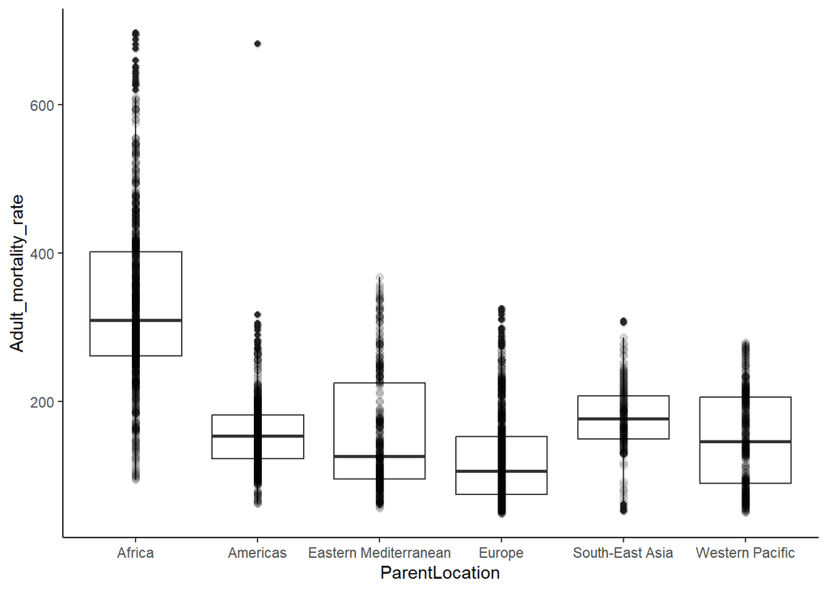

```r
## Generating a boxplot
# boxplot with raw data
ggplot(Mortality, aes(x=ParentLocation, y=Adult_mortality_rate))+
  geom_boxplot()+ # shows range of data
  geom_point(alpha=0.15, size=2)+ # shows the raw data (you can also use geom_point())
  theme_classic()
```

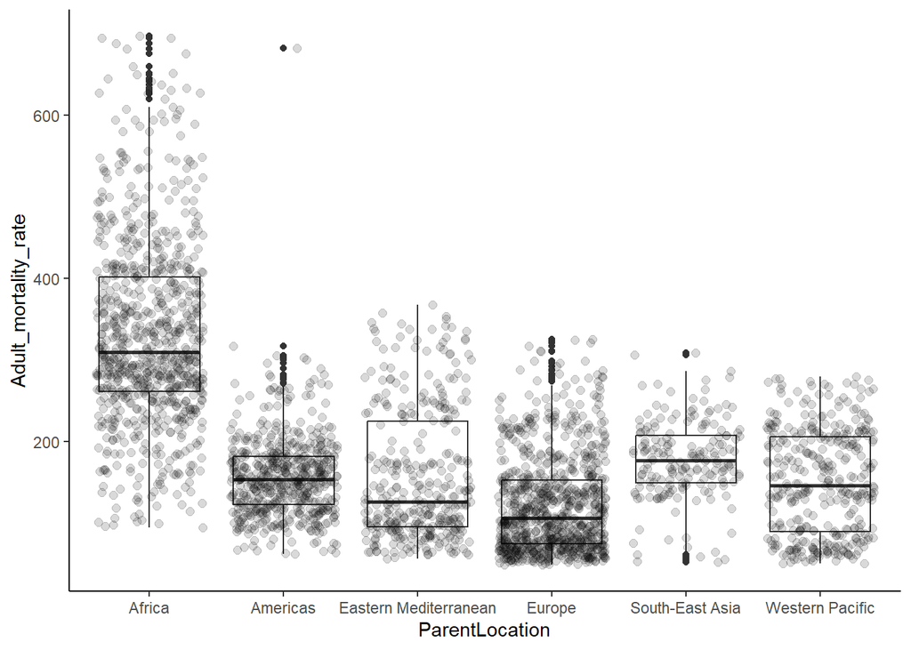

```r
# boxplot with jittered raw data
ggplot(Mortality, aes(x=ParentLocation, y=Adult_mortality_rate))+
  geom_boxplot()+ # shows range of data
  geom_jitter(alpha=0.15, size=2, height = 0, width = 0.4)+ # shows the raw data (you can also use geom_point())
  theme_classic()
```

```r
# Note that by default, built up layers inherit information from ggplot, unless otherwise stated.
```

### 3. Scatterplot customization

We will use the Elephants_data for this purpose

```r
# You can reload the data

Elephants_data <- read_csv("./data/ElephantsMF.csv")
```

You can add colour to your plot by adding colour argument to the geom_point function. The colour value can be any of the examples shown [here](http://www.stat.columbia.edu/~tzheng/files/Rcolor.pdf). Red, Green, Blue of Hex values can also be given.

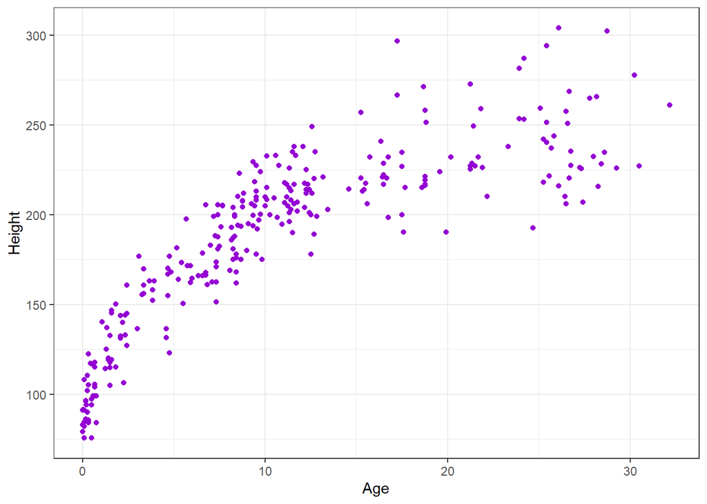

```r
ggplot(Elephants_data, aes(x=Age, y=Height))+
  geom_point(colour="darkviolet")+
  theme_bw()
```

Also, in ggplot2 colours can be treated as aesthetics of the plot. In other words we can use a column in our dataset to specify colour.

For example, we want points on our plot to be coloured according to Sex. We add an extra argument to the definition of aesthetics to define the mapping.

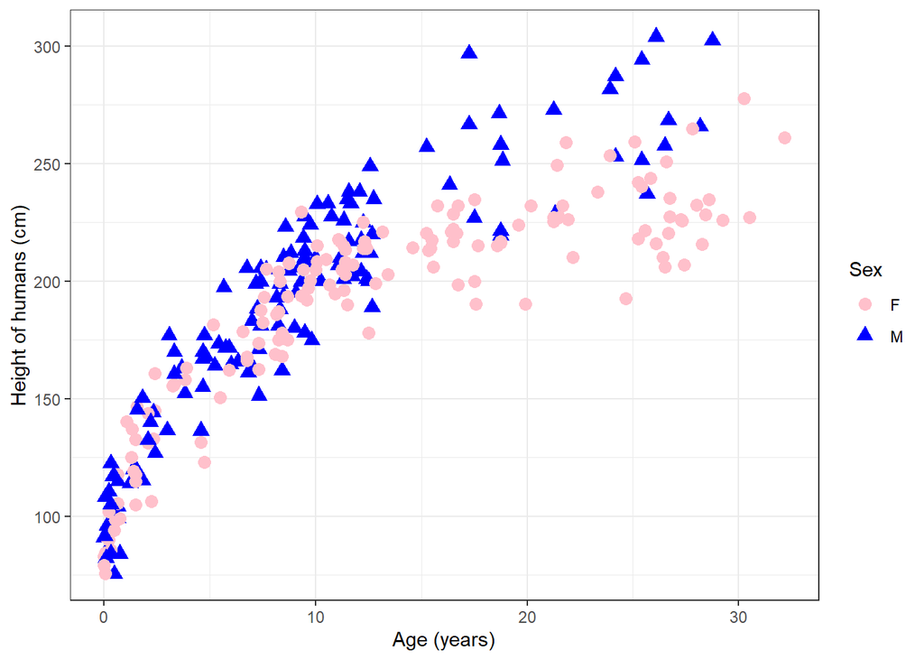

```r
ggplot(Elephants_data, aes(x=Age, y=Height, colour=Sex, shape = Sex))+
  geom_point(size=3)+
  ylab("Height of humans (cm)")+
  xlab("Age (years)")+      #change x and y axis titles
 # ylim(0,350) + xlim(0,40)+   # change the axis ranges i.e the limit of x and y axis (this is not always advisable because ggplot automatically determines the best range limit of data. Be careful using this!)
 scale_colour_manual(values = c(F = "pink", M="blue"))+ # you can add colours to change the ggplot default colours
  theme_bw() # get rid of the gray background. Use ?theme in the console environment to see other available background theme
```

```r
# It is possible to customize the non-data components of your plots: i.e. titles, labels, fonts. Use the help function for documentation e.g help(theme) or ?theme. Let's see some of the examples in the help file.
```

You can choose specific colour palettes, such as those provided by the RColorBrewer package. This package provides palettes for different types of scale.

```
library(RColorBrewer)
display.brewer.all(colorblindFriendly = TRUE)

ggplot(Elephants_data, aes(x=Age, y=Height, colour=Sex, shape = Sex))+
  geom_point(size=3)+
 scale_colour_manual(values = brewer.pal(3,"Greens"))+
  theme_bw()
```

**Exercise A**

```
Make the boxplot of Mortality data to be coloured according to "ParentLocation" while making x to be ParentLocation and y, Adult_mortality_rate.
```

Hints:

In boxplot, the colour argument changes the colour of the lines.

To change the colour of the boxes we have to use fill.

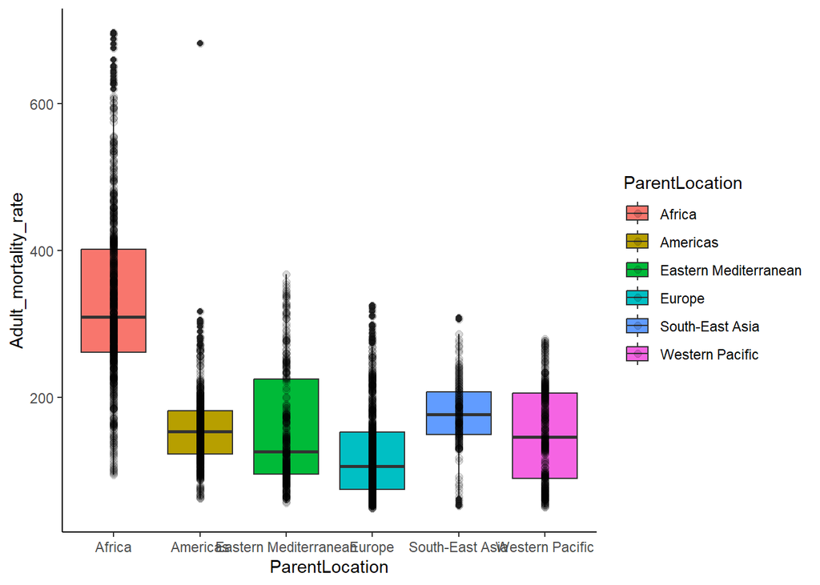

### 4. Summarising and grouping data with dplyr package in tidyverse

The summarise function can take any R function that takes a vector of values to calculate and returns a single value.

Some of the functions include:

min(): minimum value

max(): maximum value

sum(): sum of values

mean(): mean value

sd(): standard deviation

median(): median value

n(): number of observations (Note: this is a special function that does not take a vector argument and only works in the summarise function)

*** Data summaries are useful when you need to calculate means and standard deviations and also show them in graphical format.

```r
# create data summary tables and calculate the mean and standard deviation of Height(cm) in each group: Male and female.

#This is where piping operators are very useful.

Elephants_data %>%
  group_by(Sex) %>%
  summarise(
    meanHeight = mean(Height)
  )
```

```
## # A tibble: 2 x 2
##   Sex   meanHeight
##   <chr>      <dbl>
## 1 F           190.
## 2 M           185.
```

```r
# Add other summary statistics (standard deviation, standard error) to the summarized data and assign it to an object called "sumElephant"

sumElephant <- Elephants_data %>%
  group_by(Sex) %>%
  summarise(
    meanHeight = mean(Height),
    #sdHeight = sd(Height),
    seHeight = sd(Height)/sqrt(n())
    )
# Be very careful with "n()", it counts the number of rows including missing data. If you have missing values in your data, using "n()" will give a wrong result. In other to calculate a standard error when you have missing data (which might likely have in your data), you need to use some additional arguments as seen below

sumElephant2 <- Elephants_data %>%
  group_by(Sex) %>%
  summarise(
    meanHeight = mean(Height, na.rm = T),
    sdHeight = sd(Height, na.rm = T),
    seHeight = sd(Height, na.rm = T)/sqrt(sum(!is.na(Height)))
    )

# Note that you can also group by more than one variable for example group_by(Age, Height).

# Understanding how standard error function calculates the number of rows in a data with missing values

sum(!is.na(Elephants_data$Height)) #returns the sample size of non-NA to be used in calculation of the standard errors
```

```
## [1] 288
```

We can now generate a graph displaying the mean ± se.

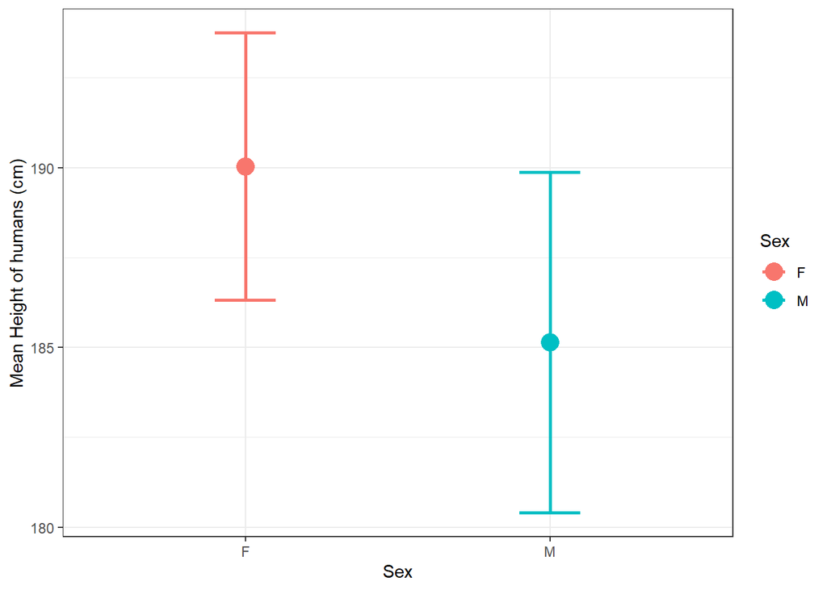

```r
# constructing a graph that displays the mean with standard errors

ggplot(sumElephant, aes(x=Sex, y=meanHeight, colour=Sex))+
  geom_point(size=5)+
  geom_errorbar(aes(ymin = meanHeight - seHeight,
                    ymax = meanHeight + seHeight),
                width = 0.2, linewidth = 1)+
  ylab("Mean Height of humans (cm)")+
  theme_bw()
```

```r
# Note that you can modify error bars arguments with 1.96*seHeight to produce and display mean ± 95% Confidence interval
```

**Exercise B**

Use ggplot() to make the figure below from the mortality data. Think about this carefully.

Hints:

As you can see on the plot, the data used does not include Africa and Europe. Hence you will need to filter out African and Europe from the the “ParentLocation” variable.

Also note that the period covers years after 2013, figure this out!

The colours correspond to Period. Here, use “as.factor()” function to convert the passed object(Period) into a Factor or a categorical variable. We did not cover it, google it! Try using the “Period” without converting it to a factor and observe the difference.

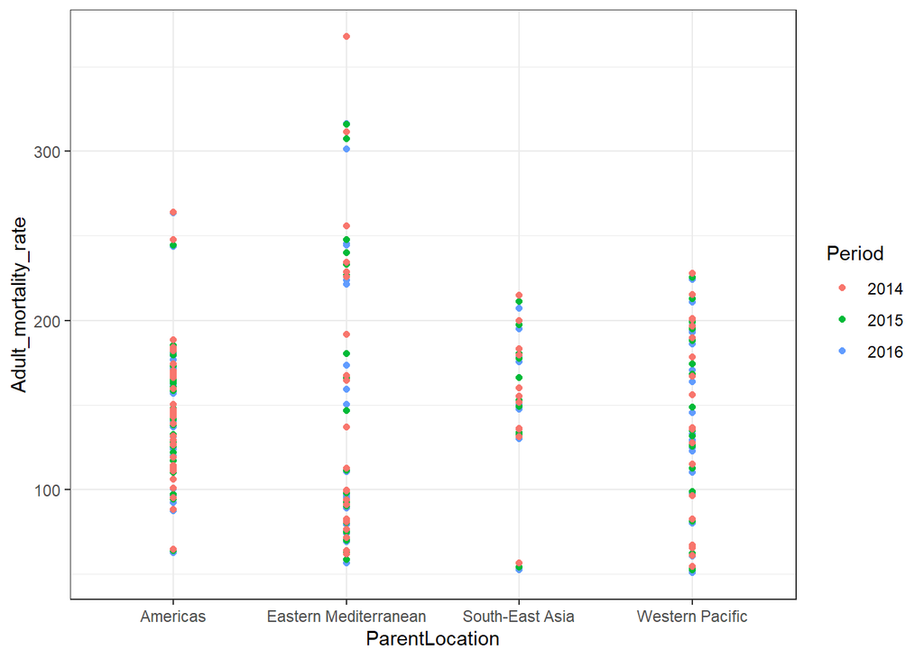

Now, we need to summarise the data

Hopefully you can see that with 3 Periods x 4 ParentLocations we have 12 groups. We can now calcucate the 12 means.

Calculate the means and standard errors and make the table below (The aim is for you to figure out how to use two grouping variables).

```
## # A tibble: 12 x 4
## # Groups:   ParentLocation [4]
##    ParentLocation        Period mean_Adult_Mortality se_Adult_Mortality
##    <chr>                 <fct>                 <dbl>              <dbl>
##  1 Americas              2014                   145.               7.35
##  2 Americas              2015                   144.               7.22
##  3 Americas              2016                   143.               7.19
##  4 Eastern Mediterranean 2014                   153.              19.2
##  5 Eastern Mediterranean 2015                   150.              17.9
##  6 Eastern Mediterranean 2016                   148.              17.8
##  7 South-East Asia       2014                   155.              12.8
##  8 South-East Asia       2015                   153.              12.8
##  9 South-East Asia       2016                   150.              12.5
## 10 Western Pacific       2014                   136.              12.6
## 11 Western Pacific       2015                   134.              12.4
## 12 Western Pacific       2016                   132.              12.4
```

Now, you will neesd to visualize the summarized data by making the plot below.

Hints:

Look closely and you will see that we have one grouping variable on the x-axis (ParentLocation) and another (Period) as colours. Think about how you do this with the aes() component of ggplot().

The big task here is to add lines connecting the dots! The data are grouped by Period. Check the ggplot help, internet and cheatsheet for the group argument and what it does.

Don’t forget to use ylab() to make that y-axis text.

You might want to bookmark [Cookbook for R](http://www.cookbook-r.com). It’s a very handy resource for ggplot graph manipulations.

Split the data into the three “Period” groups and plot each of them in their own panel - we do this with the facet_grid() layer.

Note that facet_grid() should come after the error bars layer, but before the theme_bw().

Get your x-axis tick labels rotated by adding theme(axis.text.x = element_text(angle = 45, vjust = 0.5)) after theme_bw()+

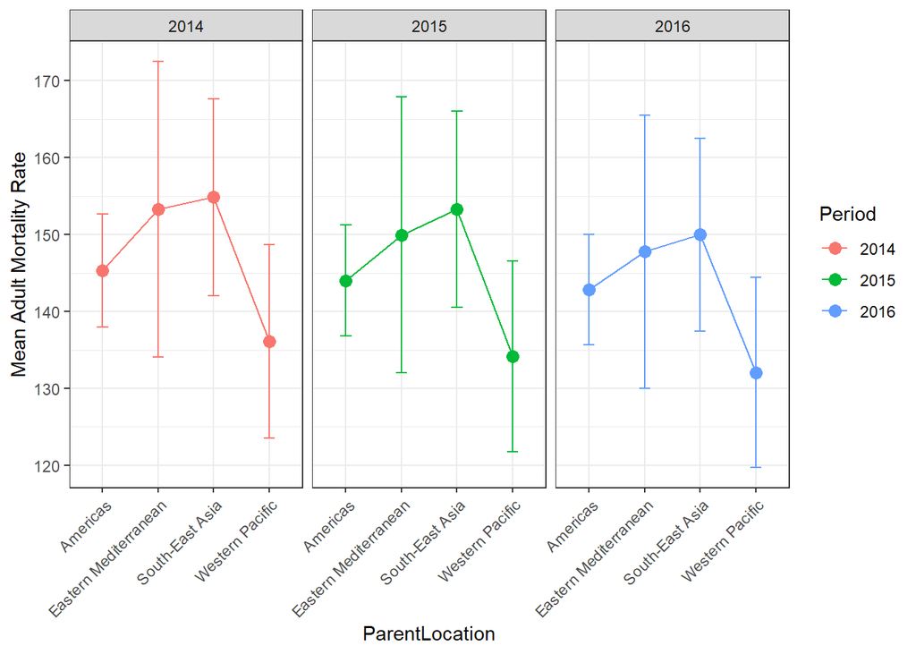

**If you have managed to successful do all of these, you now have some great R skills, congrats!**

We have come to the end of the R course section 1. The date for the other section will be communicated to you in due course. Here are the [solutions](https://lizzydapsy.github.io/R-course_materials/Solutions.html) to all the exercises.

We are now ready for the next section

**Return** to the [main course page](https://lizzydapsy.github.io/R-for-Data-Analysis/README.html) and click on “Basic statistics - t-test”.